# Multivariate Data Analysis Assignment 3

## Introduction

In this report, we are asked to analyse a dataset and present our findings.

The data that we analyse for this report is mRNA gene expression data, from 60 samples and across 2690 genes from a hypothetical (simulated) study.

The aims of this simulated study are to analyse the effects of two treatments on a cell culture. The 60 samples are split across two covariates: time (6 or 12 hours) and treatment (lisinopril, amlodipine, or control).

Our workflow first presents high-level qualities of the data. We move onto Principal Components Analysis (PCA) and Cluster Analysis, finding meaningful partitions of the data. We fit a Linear Discriminant Rule (LDR) to the data, and complete the analysis with a brief application of graph-based clustering to the same data.

## Part 1: Exploratory Data Analysis

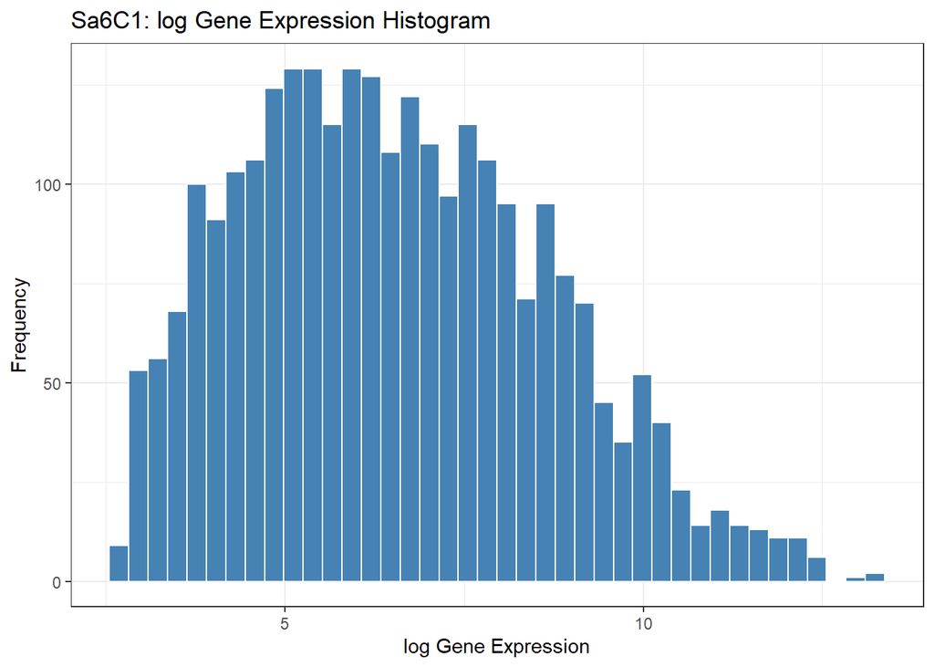

Histogram Displaying Logarithm of Gene Expression

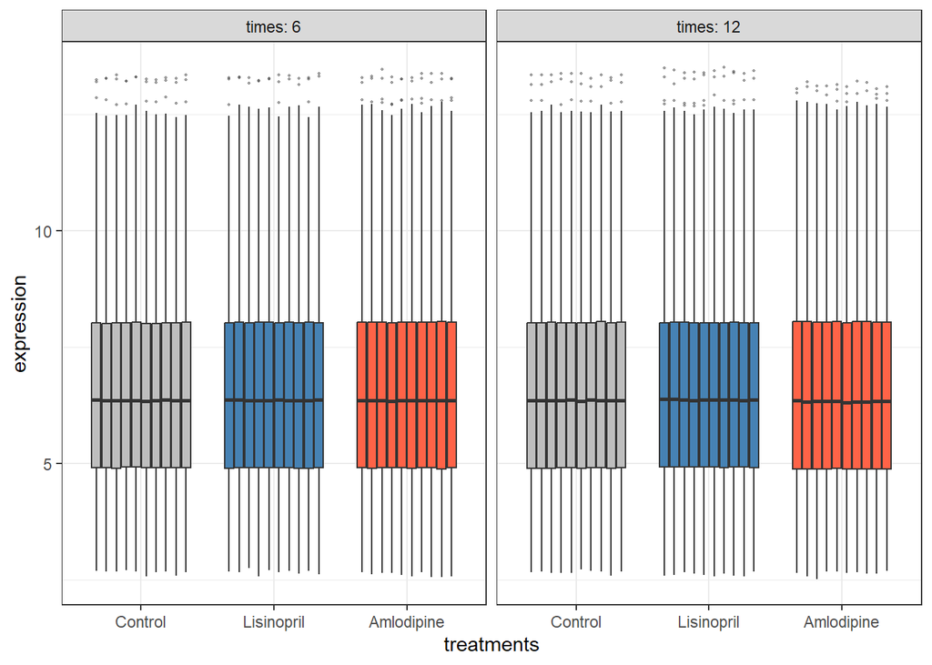

Boxplot Displaying Distribution of Log Gene Expressions, Split by Covariates

Figures @ref(fig:fig-histogram) and @ref(fig:fig-boxplot) display the distributions of gene expression over our 60 samples. Note the logarithm of the gene expression is given instead of the raw expression value, as the data is given to us in log-normalised form. Then, when plotting the data in our histogram, we see a distribution that resembles a Gaussian one. This we expect.

From @ref(fig:fig-boxplot), we can see that the distributions of expression are not affected to large extent by either of time or treatment. Nor is there much variation between replicates.

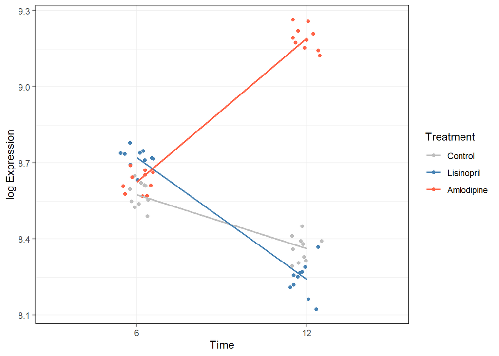

Time Course for Gene 1415670_at

Here in Figure @ref(fig:fig-timecourse) we examine the differences between those samples sequenced at time 6 and those at time 12. We can see a decrease in expression in the case of the control and lisinopril treatments, contrasted with an increase in that of amlodipine.

## Part 2: Prinicpal Components Analysis

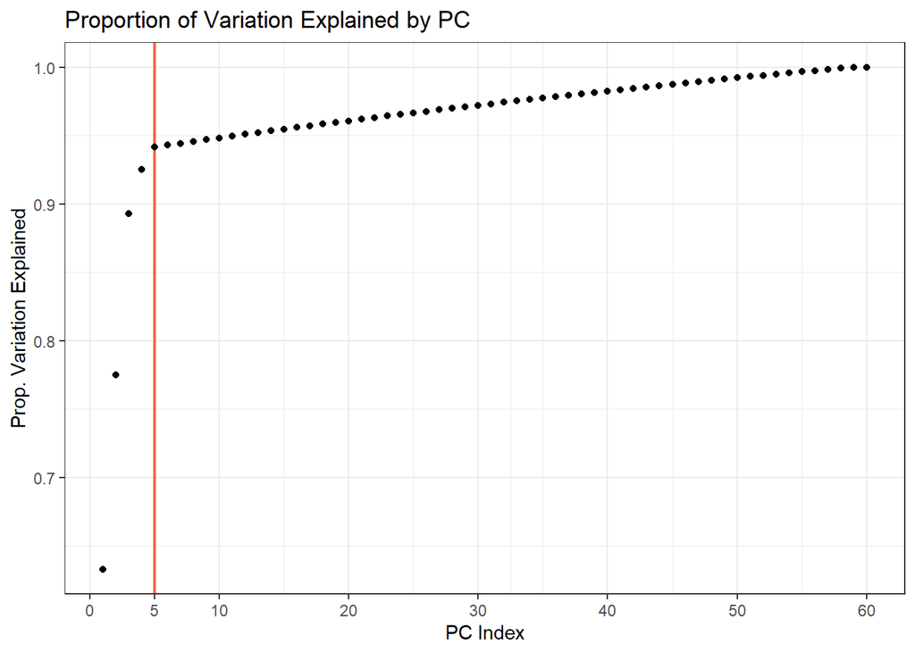

Plot of Variation Explained per PC

We can confidently choose a value of 5 principal components for downstream analysis. Here we have used an elbow plot method, but can be confident in our low-dimensional representation as these first 5 PCs explain 0.9414508 of the variation.

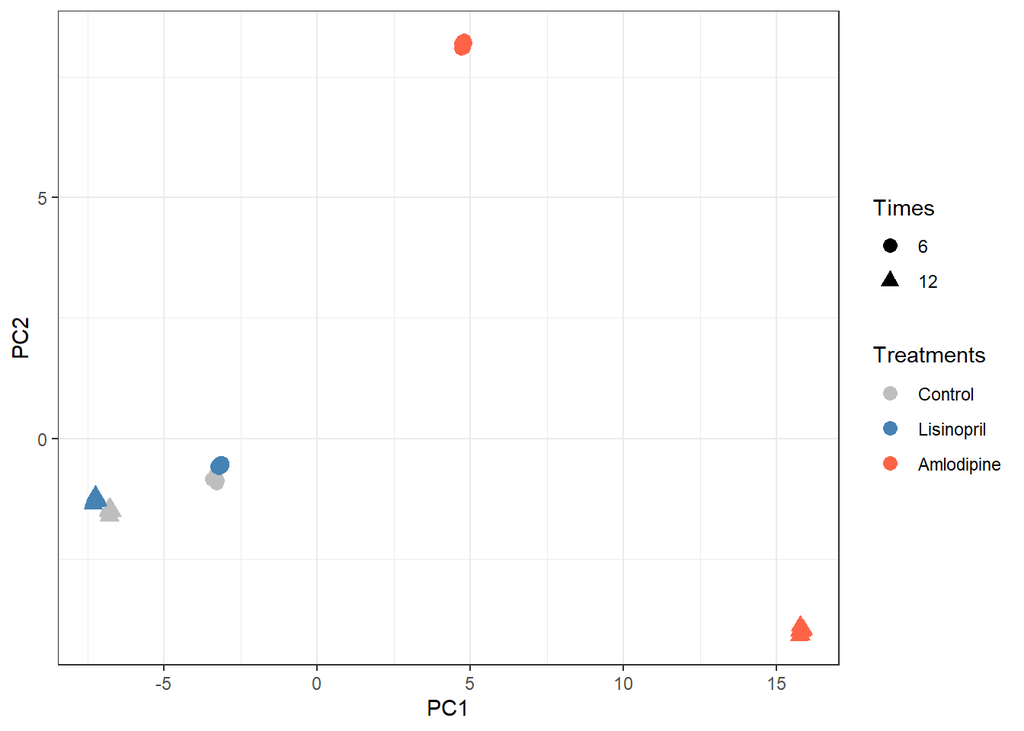

Plot of the first two PCs against each other.

It is clear to see that we will be able to split by these covariates. The plot gives confidence that we will be able to describe a partition obtained through cluster or discriminant analysis in terms of these covariates.

## Part 3: Cluster Analysis

In cluster analysis, we look for meaningful partitions of our data. The two methods we have elected for comparison are KMeans and Hierarchical clustering.

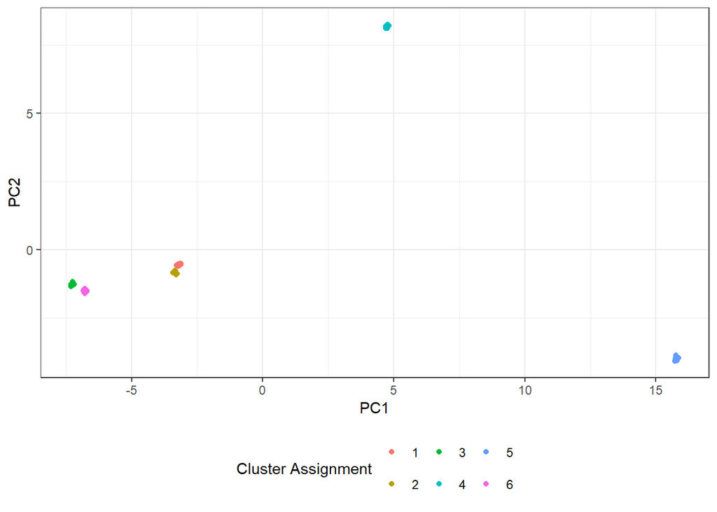

Plot of the Partition Obtained by KMeans

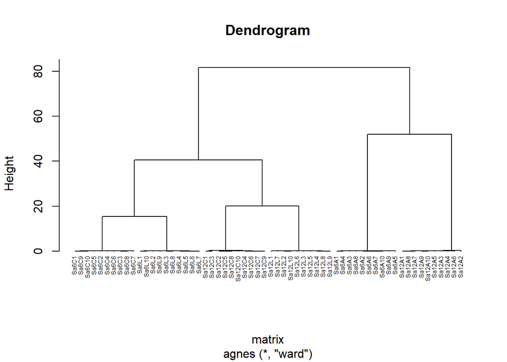

Plot of the Partition Obtained by Hierarchical

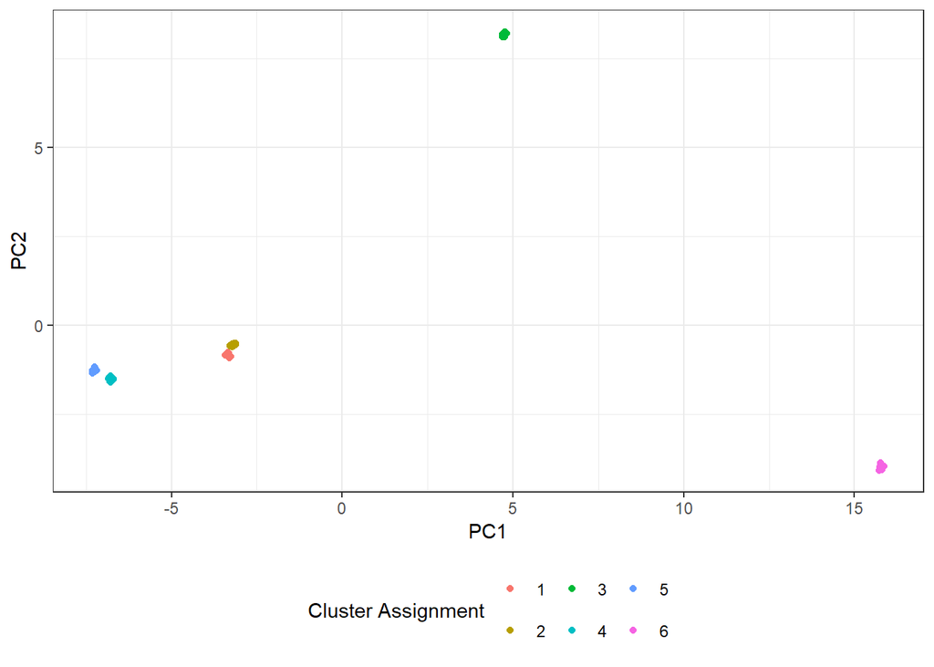

Plot of the Partition Obtained by Hierarchical

Chi-square tests: clustering vs experimental variables

| Comparison | X-squared | df | p-value |
| --- | --- | --- | --- |
| KMeans ~ Treatments | 120 | 10 | 5.060000e-21 |
| KMeans ~ Times | 60 | 5 | 1.215457e-11 |
| Hierarchical ~ Treatments | 120 | 10 | 5.060000e-21 |
| Hierarchical ~ Times | 60 | 5 | 1.215457e-11 |

```
##
##  Pearson's Chi-squared test
##
## data:  table(K_clustering, D$treatments)
## X-squared = 120, df = 10, p-value < 2.2e-16
```

```
##
##  Pearson's Chi-squared test
##
## data:  table(K_clustering, D$times)
## X-squared = 60, df = 5, p-value = 1.215e-11
```

```
##
##  Pearson's Chi-squared test
##
## data:  table(H_clustering$cluster, D$treatments)
## X-squared = 120, df = 10, p-value < 2.2e-16
```

```
##
##  Pearson's Chi-squared test
##
## data:  table(H_clustering$cluster, D$times)
## X-squared = 60, df = 5, p-value = 1.215e-11
```

Comparison of Hierarchical and KMeans Partitions

| 1 | 2 | 3 | 4 | 5 | 6 |
| --- | --- | --- | --- | --- | --- |
| 0 | 10 | 0 | 0 | 0 | 0 |
| 10 | 0 | 0 | 0 | 0 | 0 |
| 0 | 0 | 0 | 10 | 0 | 0 |
| 0 | 0 | 0 | 0 | 0 | 10 |
| 0 | 0 | 10 | 0 | 0 | 0 |
| 0 | 0 | 0 | 0 | 10 | 0 |

```
## $Silhouette
## [1] 0.9776802
##
## $VRC
## [1] 86933.48
##
## $Gap
##      gap
## 3.626449
```

```
## $Silhouette
## [1] 0.9776802
##
## $VRC
## [1] 86933.48
##
## $Gap
##      gap
## 3.625004
```

## Part 4: Discriminant Analysis

```
##     predicted
##       6 12
##   6  30  0
##   12  0 30
```

```
##
##  Pearson's Chi-squared test with Yates' continuity correction
##
## data:  table(D$times, predicted)
## X-squared = 56.067, df = 1, p-value = 7.005e-14
```

Here we seek to fit a linear discriminant rule to classify which timestamp each sample has attached to it, as this is a factor variable with two levels.

From our discriminant analysis, we see that we have acheived perfect separation. This tells us that within our low-dimensional representation of the data, there is no overlap between the groups belonging to each timestamp.

## Part 5: Extension to Graph-Based Clustering

In contemporary mRNA sequencing workflows, alternative cluster analysis methods are commonly employed. One such is the Louvain algorithm. It is graph-based, rather than acting on the expression or similarity matrix directly.

Here we demonstrate its results on the same data as an extension of the cluster analysis in Part 3.

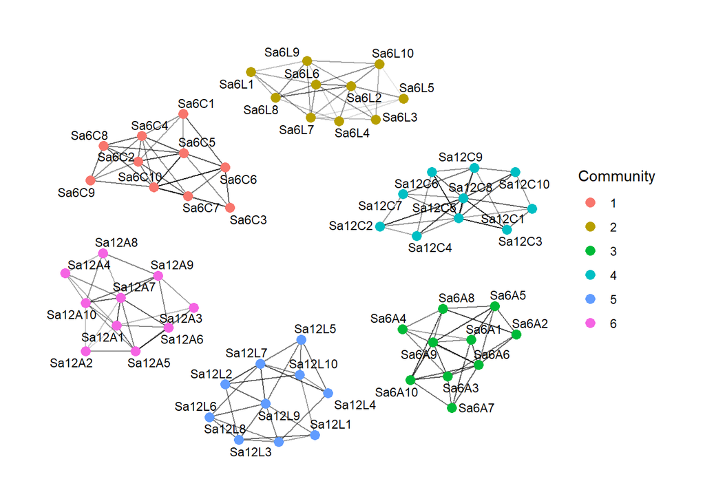